# Ford GoBike System Data Analysis

## by Abdallah Badran

## Investigation Overview

> In this analysis we investigate several factors that may affect a biker trip duration and other insights in common with most of the trips

## Dataset Overview

> The dataset consists of 183412 members of Ford GoBike system with 19 fetaures after perfoming some feature engineering and data wrangling. The attributes include the trip duration, age, start and end stations, gender and others

## Distribution of trips' durations

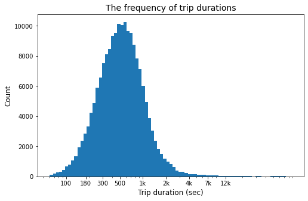

```python
# The distribution of trips' durations in a log scale
bins = 10 ** np.arange(np.log10(df['duration_sec']).min(), np.log10(df['duration_sec']).max()+0.04, 0.04)
hist('duration_sec', bins, 'Trip duration (sec)', 'Count', 'The frequency of trip durations')
plt.xscale('log')
ticks = [100, 180, 300, 500, 1000, 2000, 4000 ,7000 ,12000]
ticks_labels = ['100', '180', '300', '500', '1k', '2k', '4k' ,'7k' ,'12k']
plt.xticks(ticks, ticks_labels);
```

## Distribution of start hour

> The distribution of start hours is bimodal with one peak at 8 am and the other peak is at 5 pm (17).

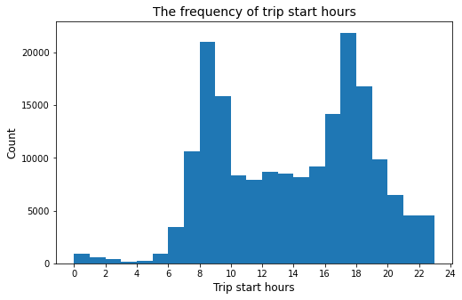

```python
# The distribution of the start hours
bins = np.arange(0, 23+1, 1)
hist('start_hour', bins, 'Trip start hours', 'Count', 'The frequency of trip start hours')
plt.xticks(np.arange(0, 25, 2), np.arange(0, 25, 2));
```

## Start hour Vs trip duration

> Members that start their trips at 2 am or 3 am have the longest trip duartions on average.

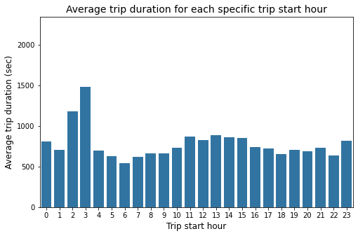

```python
# Start hour Vs trip duration
categ_quant('start_hour', 'duration_sec', 'Trip start hour', 'Average trip duration (sec)', 'Average trip duration for each specific trip start hour')
```

## User type Vs trip duration

> Customers have larger trip durations than subscribers in average, customers have about 1400 seconds (23 minutes) while subscribers have about 600 seconds (10 minutes) in average.

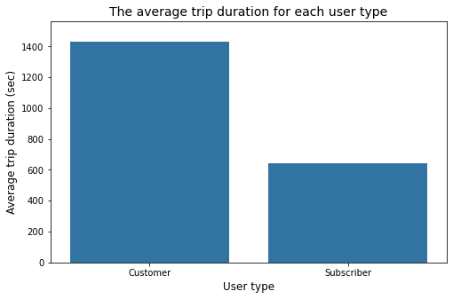

```python
# Investigating duration-user_type relationship
categ_quant('user_type', 'duration_sec', 'User type', 'Average trip duration (sec)', 'The average trip duration for each user type')
```